# 迴歸分析(一)

Shu Yu Liu

# Weld data

For the data weld.txt, a study is done to compare three metal alloys used to make welds to join pipes together. Y = a measure of the strength of the weld, X = diameter of weld, Alloy = type of alloy used to make the weld.

```
##    ALLOY Strength Diameter
## 1      1     37.5     12.5
## 2      1     40.5     14.0
## 3      1     49.0     16.0
## 4      1     51.0     15.0
## 5      1     61.5     18.0
## 6      1     63.0     19.5
## 7      2     57.5     16.5
## 8      2     69.5     17.5
## 9      2     87.0     19.0
## 10     2     92.0     19.5
## 11     2    107.0     20.4
## 12     2    119.5     22.5
## 13     3     38.0     15.5
## 14     3     44.5     16.0
## 15     3     53.0     19.0
## 16     3     55.0     18.0
## 17     3     58.5     19.0
## 18     3     60.0     20.5
```

## EDA

Build multiple linear regression model, “mlr”.

```
##
## Call:
## glm(formula = Strength ~ Diameter + ALLOY, data = weld)
##
## Coefficients:
##             Estimate Std. Error t value Pr(>|t|)
## (Intercept) -45.2566    14.5265  -3.115  0.00760 **
## Diameter      6.0425     0.8956   6.747 9.36e-06 ***
## ALLOY2       17.7887     5.4018   3.293  0.00534 **
## ALLOY3      -12.0088     4.8655  -2.468  0.02708 *
## ---
## Signif. codes:  0 '***' 0.001 '**' 0.01 '*' 0.05 '.' 0.1 ' ' 1
##
## (Dispersion parameter for gaussian family taken to be 59.72491)
##
##     Null deviance: 9271.44  on 17  degrees of freedom
## Residual deviance:  836.15  on 14  degrees of freedom
## AIC: 130.17
##
## Number of Fisher Scoring iterations: 2
```

Scatter plot of the Strength versus Diameter.

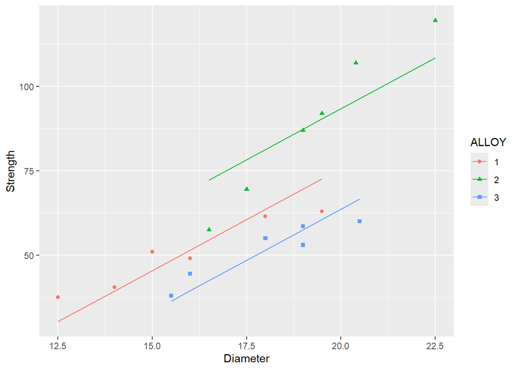

## Explanation

Model: Strength = -45.2566 + 6.0425Diameter + 17.7887ALLOY2 -12.0088ALLOY3

The model demonstrate that if the the diameter of the weld increasing by one unit, the mean strength of weld will increase by 6.0425.

The estimated mean difference in strength of weld between alloys1 and alloys 3 is -12.0088 at any values of diameter of weld.

The estimated regression line for alloys 1. Strength = -45.2566 + 6.0425Diameter

The estimated regression line for alloys 2. Strength = -27.4679 + 6.0425Diameter

The estimated regression line for alloys 3. Strength = -57.2654 + 6.0425Diameter

## Residual plot

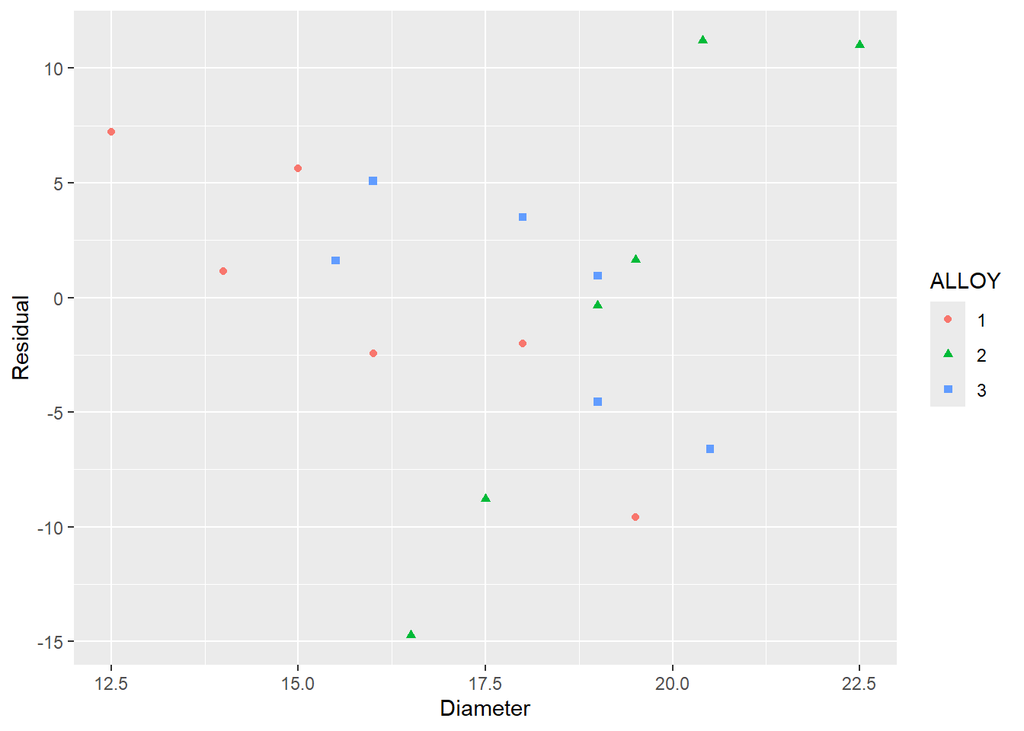

## Improvement

Error term is nonnormality and unequal variances. Transform Y variable(Strength) can improve the problem.

## Consider an “interaction” model

```
##
## Call:
## glm(formula = Strength ~ Diameter + ALLOY + Diameter * ALLOY,
##     data = weld)
##
## Coefficients:
##                  Estimate Std. Error t value Pr(>|t|)
## (Intercept)      -11.6500     9.2987  -1.253    0.234
## Diameter           3.9200     0.5809   6.748 2.05e-05 ***
## ALLOY2          -105.0766    16.4977  -6.369 3.56e-05 ***
## ALLOY3           -12.2554    16.8916  -0.726    0.482
## Diameter:ALLOY2    6.7634     0.9134   7.404 8.23e-06 ***
## Diameter:ALLOY3    0.2692     0.9723   0.277    0.787
## ---
## Signif. codes:  0 '***' 0.001 '**' 0.01 '*' 0.05 '.' 0.1 ' ' 1
##
## (Dispersion parameter for gaussian family taken to be 11.24766)
##
##     Null deviance: 9271.44  on 17  degrees of freedom
## Residual deviance:  134.97  on 12  degrees of freedom
## AIC: 101.35
##
## Number of Fisher Scoring iterations: 2
```

## Explanation

Model: Strength = -11.6500 + 3.9200Diameter - 105.0766alloy2 - 12.2554alloy3 + 6.7634Diameter x alloy2 + 0.2692Diameter x alloy3

Estimated regression line for alloys 1. Strength = -11.6500 + 3.9200Diameter

Estimated regression line for alloys 2. Strength = -116.7266 + 10.6834Diameter

Estimated regression line for alloys 3. Strength = -23.9054 + 4.1892Diameter

According to the third regression line, if the diameter differ by one unit, the estimated difference in the mean strength will be 4.1892.

When the values of diameter is 5.0, the estimated mean difference in strength between alloys 1 and alloys 3 will be 10.9094.

## Improvement

According to the p-value in the model, it is suggested to drop the variable Diameter:ALLOY3 because the p-value is not significant. Even though the p-value of ALLOY3 is also non-significant, it is kept to properly separate the interaction terms for the Alloy factor.

The model suggests that Alloy 2 is the ‘special’ case. Further research might consider a simplified model that only distinguishes ‘Alloy 2’ vs. ‘Others’ if Alloy 1 and 3 are indeed practically similar.

# Cement data

In this data set, the response Y measures the heat evolved in calories during the hardening of cement on a per gram basis. The four predictors are the percentages of four ingredients: tricalcium aluminate (X1), tricalcium silicate (X2), tetracalcium alumino ferrite (X3) , and dicalcium silicate (X4).

```
##        y x1 x2 x3 x4
## 1   78.5  7 26  6 60
## 2   74.3  1 29 15 52
## 3  104.3 11 56  8 20
## 4   87.6 11 31  8 47
## 5   95.9  7 52  6 33
## 6  109.2 11 55  9 22
## 7  102.7  3 71 17  6
## 8   72.5  1 31 22 44
## 9   93.1  2 54 18 22
## 10 115.9 21 47  4 26
## 11  83.8  1 40 23 34
## 12 113.3 11 66  9 12
## 13 109.4 10 68  8 12
```

## Build model

```
##
## Call:
## lm(formula = y ~ x1 + x2 + x3 + x4, data = cement)
##
## Residuals:
##     Min      1Q  Median      3Q     Max
## -3.1750 -1.6709  0.2508  1.3783  3.9254
##
## Coefficients:
##             Estimate Std. Error t value Pr(>|t|)
## (Intercept)  62.4054    70.0710   0.891   0.3991
## x1            1.5511     0.7448   2.083   0.0708 .
## x2            0.5102     0.7238   0.705   0.5009
## x3            0.1019     0.7547   0.135   0.8959
## x4           -0.1441     0.7091  -0.203   0.8441
## ---
## Signif. codes:  0 '***' 0.001 '**' 0.01 '*' 0.05 '.' 0.1 ' ' 1
##
## Residual standard error: 2.446 on 8 degrees of freedom
## Multiple R-squared:  0.9824, Adjusted R-squared:  0.9736
## F-statistic: 111.5 on 4 and 8 DF,  p-value: 4.756e-07
```

## Problems

The p-values for individual variable tests are all greater than 0.05, indicating that the effect of each variable on $Y$ is not significant. However, the F-test result is significant, which suggests that multicollinearity may be present.

```
##             y         x1         x2         x3         x4
## y   1.0000000  0.7307175  0.8162526 -0.5346707 -0.8213050
## x1  0.7307175  1.0000000  0.2285795 -0.8241338 -0.2454451
## x2  0.8162526  0.2285795  1.0000000 -0.1392424 -0.9729550
## x3 -0.5346707 -0.8241338 -0.1392424  1.0000000  0.0295370
## x4 -0.8213050 -0.2454451 -0.9729550  0.0295370  1.0000000
```

According to the correlation matrix, there are multicollinearity issues between $x_1$ and $x_3$, as well as between $x_2$ and $x_4$.